# SLF_Project_LearnerNotebook_FullCode

```python
!pip install numpy pandas scipy matplotlib seaborn tensorflow statsmodels sklearn nb-black
```

```python
# this will help in making the Python code more structured automatically (good coding practice)
%load_ext nb_black

# Libraries to help with reading and manipulating data
import numpy as np
import pandas as pd

# Libraries to help with data visualization
import matplotlib.pyplot as plt
import seaborn as sns

sns.set()

# split the data into train and test
from sklearn.model_selection import train_test_split

# to build linear regression_model
from sklearn.linear_model import LinearRegression

# to check model performance
from sklearn.metrics import mean_absolute_error, mean_squared_error, r2_score

# to build linear regression_model using statsmodels
import statsmodels.api as sm

# to compute VIF
from statsmodels.stats.outliers_influence import variance_inflation_factor
```

## Importing necessary libraries

## Loading the dataset

```python
# loading data
data = pd.read_csv("used_device_data.csv")  ## Loading the data
```

## Data Overview

- Observations
- Sanity checks

### Displaying the first few rows of the dataset

```python
# returns the first 5 rows
data.head()
```

|  | brand_name | os | screen_size | 4g | 5g | main_camera_mp | selfie_camera_mp | int_memory | ram | battery | weight | release_year | days_used | normalized_used_price | normalized_new_price |
| --- | --- | --- | --- | --- | --- | --- | --- | --- | --- | --- | --- | --- | --- | --- | --- |
| 0 | Honor | Android | 14.50 | yes | no | 13.0 | 5.0 | 64.0 | 3.0 | 3020.0 | 146.0 | 2020 | 127 | 4.307572 | 4.715100 |
| 1 | Honor | Android | 17.30 | yes | yes | 13.0 | 16.0 | 128.0 | 8.0 | 4300.0 | 213.0 | 2020 | 325 | 5.162097 | 5.519018 |
| 2 | Honor | Android | 16.69 | yes | yes | 13.0 | 8.0 | 128.0 | 8.0 | 4200.0 | 213.0 | 2020 | 162 | 5.111084 | 5.884631 |
| 3 | Honor | Android | 25.50 | yes | yes | 13.0 | 8.0 | 64.0 | 6.0 | 7250.0 | 480.0 | 2020 | 345 | 5.135387 | 5.630961 |
| 4 | Honor | Android | 15.32 | yes | no | 13.0 | 8.0 | 64.0 | 3.0 | 5000.0 | 185.0 | 2020 | 293 | 4.389995 | 4.947837 |

#### Displaying the last few rows of the dataset

```python
# returns the last 5 rows
data.tail()
```

|  | brand_name | os | screen_size | 4g | 5g | main_camera_mp | selfie_camera_mp | int_memory | ram | battery | weight | release_year | days_used | normalized_used_price | normalized_new_price |
| --- | --- | --- | --- | --- | --- | --- | --- | --- | --- | --- | --- | --- | --- | --- | --- |
| 3449 | Asus | Android | 15.34 | yes | no | NaN | 8.0 | 64.0 | 6.0 | 5000.0 | 190.0 | 2019 | 232 | 4.492337 | 6.483872 |
| 3450 | Asus | Android | 15.24 | yes | no | 13.0 | 8.0 | 128.0 | 8.0 | 4000.0 | 200.0 | 2018 | 541 | 5.037732 | 6.251538 |
| 3451 | Alcatel | Android | 15.80 | yes | no | 13.0 | 5.0 | 32.0 | 3.0 | 4000.0 | 165.0 | 2020 | 201 | 4.357350 | 4.528829 |
| 3452 | Alcatel | Android | 15.80 | yes | no | 13.0 | 5.0 | 32.0 | 2.0 | 4000.0 | 160.0 | 2020 | 149 | 4.349762 | 4.624188 |
| 3453 | Alcatel | Android | 12.83 | yes | no | 13.0 | 5.0 | 16.0 | 2.0 | 4000.0 | 168.0 | 2020 | 176 | 4.132122 | 4.279994 |

### Checking the shape of the dataset

```python
# returns shape of dataset
data.shape
```

```
(3454, 15)
```

- There are 3454 rows and 15 columns in the dataset.

### Checking the data types of the columns for the dataset

```python
# returns concise summary of the DataFrame
data.info()
```

```
<class 'pandas.core.frame.DataFrame'>
RangeIndex: 3454 entries, 0 to 3453
Data columns (total 15 columns):
 #   Column                 Non-Null Count  Dtype
---  ------                 --------------  -----
 0   brand_name             3454 non-null   object
 1   os                     3454 non-null   object
 2   screen_size            3454 non-null   float64
 3   4g                     3454 non-null   object
 4   5g                     3454 non-null   object
 5   main_camera_mp         3275 non-null   float64
 6   selfie_camera_mp       3452 non-null   float64
 7   int_memory             3450 non-null   float64
 8   ram                    3450 non-null   float64
 9   battery                3448 non-null   float64
 10  weight                 3447 non-null   float64
 11  release_year           3454 non-null   int64
 12  days_used              3454 non-null   int64
 13  normalized_used_price  3454 non-null   float64
 14  normalized_new_price   3454 non-null   float64
dtypes: float64(9), int64(2), object(4)
memory usage: 404.9+ KB
```

- 11 out of the 15 columns are numerical columns and the remaining 4 are object type columns

### Statistical summary of the dataset

```python
data.describe(include="all").T
```

|  | count | unique | top | freq | mean | std | min | 25% | 50% | 75% | max |
| --- | --- | --- | --- | --- | --- | --- | --- | --- | --- | --- | --- |
| brand_name | 3454 | 34 | Others | 502 | NaN | NaN | NaN | NaN | NaN | NaN | NaN |
| os | 3454 | 4 | Android | 3214 | NaN | NaN | NaN | NaN | NaN | NaN | NaN |
| screen_size | 3454.0 | NaN | NaN | NaN | 13.713115 | 3.80528 | 5.08 | 12.7 | 12.83 | 15.34 | 30.71 |
| 4g | 3454 | 2 | yes | 2335 | NaN | NaN | NaN | NaN | NaN | NaN | NaN |
| 5g | 3454 | 2 | no | 3302 | NaN | NaN | NaN | NaN | NaN | NaN | NaN |
| main_camera_mp | 3275.0 | NaN | NaN | NaN | 9.460208 | 4.815461 | 0.08 | 5.0 | 8.0 | 13.0 | 48.0 |
| selfie_camera_mp | 3452.0 | NaN | NaN | NaN | 6.554229 | 6.970372 | 0.0 | 2.0 | 5.0 | 8.0 | 32.0 |
| int_memory | 3450.0 | NaN | NaN | NaN | 54.573099 | 84.972371 | 0.01 | 16.0 | 32.0 | 64.0 | 1024.0 |
| ram | 3450.0 | NaN | NaN | NaN | 4.036122 | 1.365105 | 0.02 | 4.0 | 4.0 | 4.0 | 12.0 |
| battery | 3448.0 | NaN | NaN | NaN | 3133.402697 | 1299.682844 | 500.0 | 2100.0 | 3000.0 | 4000.0 | 9720.0 |
| weight | 3447.0 | NaN | NaN | NaN | 182.751871 | 88.413228 | 69.0 | 142.0 | 160.0 | 185.0 | 855.0 |
| release_year | 3454.0 | NaN | NaN | NaN | 2015.965258 | 2.298455 | 2013.0 | 2014.0 | 2015.5 | 2018.0 | 2020.0 |
| days_used | 3454.0 | NaN | NaN | NaN | 674.869716 | 248.580166 | 91.0 | 533.5 | 690.5 | 868.75 | 1094.0 |
| normalized_used_price | 3454.0 | NaN | NaN | NaN | 4.364712 | 0.588914 | 1.536867 | 4.033931 | 4.405133 | 4.7557 | 6.619433 |
| normalized_new_price | 3454.0 | NaN | NaN | NaN | 5.233107 | 0.683637 | 2.901422 | 4.790342 | 5.245892 | 5.673718 | 7.847841 |

### Checking for duplicate values

```python
data.duplicated().sum()
```

```
0
```

- There are no duplicate value in the data set.

### Checking for missing values

```python
data.isnull().sum()
```

```
brand_name                 0
os                         0
screen_size                0
4g                         0
5g                         0
main_camera_mp           179
selfie_camera_mp           2
int_memory                 4
ram                        4
battery                    6
weight                     7
release_year               0
days_used                  0
normalized_used_price      0
normalized_new_price       0
dtype: int64
```

- There are missing values in 6 columns.

```python
# creating a copy of the data so that original data remains unchanged
df = data.copy()
```

## Exploratory Data Analysis (EDA)

- EDA is an important part of any project involving data.
- It is important to investigate and understand the data better before building a model with it.
- A few questions have been mentioned below which will help you approach the analysis in the right manner and generate insights from the data.
- A thorough analysis of the data, in addition to the questions mentioned below, should be done.

**Questions**:

1. What does the distribution of normalized used device prices look like?
2. What percentage of the used device market is dominated by Android devices?
3. The amount of RAM is important for the smooth functioning of a device. How does the amount of RAM vary with the brand?
4. A large battery often increases a device's weight, making it feel uncomfortable in the hands. How does the weight vary for phones and tablets offering large batteries (more than 4500 mAh)?
5. Bigger screens are desirable for entertainment purposes as they offer a better viewing experience. How many phones and tablets are available across different brands with a screen size larger than 6 inches?
6. A lot of devices nowadays offer great selfie cameras, allowing us to capture our favorite moments with loved ones. What is the distribution of devices offering greater than 8MP selfie cameras across brands?
7. Which attributes are highly correlated with the normalized price of a used device?

### Univariate Analysis

```python
def histogram_boxplot(data, feature, figsize=(15, 10), kde=False, bins=None):
    """
    Boxplot and histogram combined

    data: dataframe
    feature: dataframe column
    figsize: size of figure (default (15,10))
    kde: whether to show the density curve (default False)
    bins: number of bins for histogram (default None)
    """
    f2, (ax_box2, ax_hist2) = plt.subplots(
        nrows=2,  # Number of rows of the subplot grid= 2
        sharex=True,  # x-axis will be shared among all subplots
        gridspec_kw={"height_ratios": (0.25, 0.75)},
        figsize=figsize,
    )  # creating the 2 subplots
    sns.boxplot(
        data=data, x=feature, ax=ax_box2, showmeans=True, color="violet"
    )  # boxplot will be created and a triangle will indicate the mean value of the column
    sns.histplot(
        data=data, x=feature, kde=kde, ax=ax_hist2, bins=bins
    ) if bins else sns.histplot(
        data=data, x=feature, kde=kde, ax=ax_hist2
    )  # For histogram
    ax_hist2.axvline(
        data[feature].mean(), color="green", linestyle="--"
    )  # Add mean to the histogram
    ax_hist2.axvline(
        data[feature].median(), color="black", linestyle="-"
    )  # Add median to the histogram
```

```python
# function to create labeled barplots


def labeled_barplot(data, feature, perc=False, n=None):
    """
    Barplot with percentage at the top

    data: dataframe
    feature: dataframe column
    perc: whether to display percentages instead of count (default is False)
    n: displays the top n category levels (default is None, i.e., display all levels)
    """

    total = len(data[feature])  # length of the column
    count = data[feature].nunique()
    if n is None:
        plt.figure(figsize=(count + 2, 6))
    else:
        plt.figure(figsize=(n + 2, 6))

    plt.xticks(rotation=90, fontsize=15)
    ax = sns.countplot(
        data=data,
        x=feature,
        palette="Paired",
        order=data[feature].value_counts().index[:n],
    )

    for p in ax.patches:
        if perc == True:
            label = "{:.1f}%".format(
                100 * p.get_height() / total
            )  # percentage of each class of the category
        else:
            label = p.get_height()  # count of each level of the category

        x = p.get_x() + p.get_width() / 2  # width of the plot
        y = p.get_height()  # height of the plot

        ax.annotate(
            label,
            (x, y),
            ha="center",
            va="center",
            size=12,
            xytext=(0, 5),
            textcoords="offset points",
        )  # annotate the percentage

    plt.show()  # show the plot
```

**What does the distribution of normalized used device prices look like?**

**`normalized_used_price`**

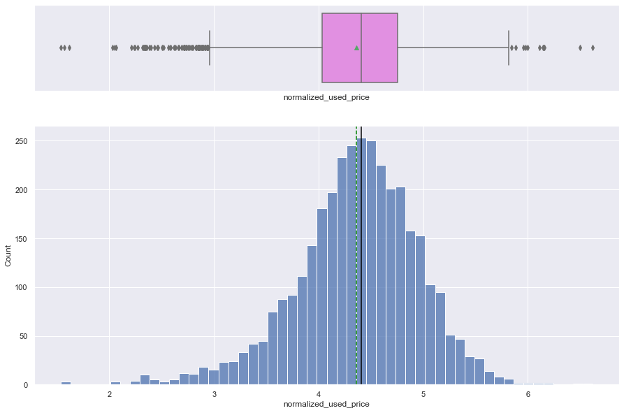

```python
histogram_boxplot(df, "normalized_used_price")
```

**`normalized_new_price`**

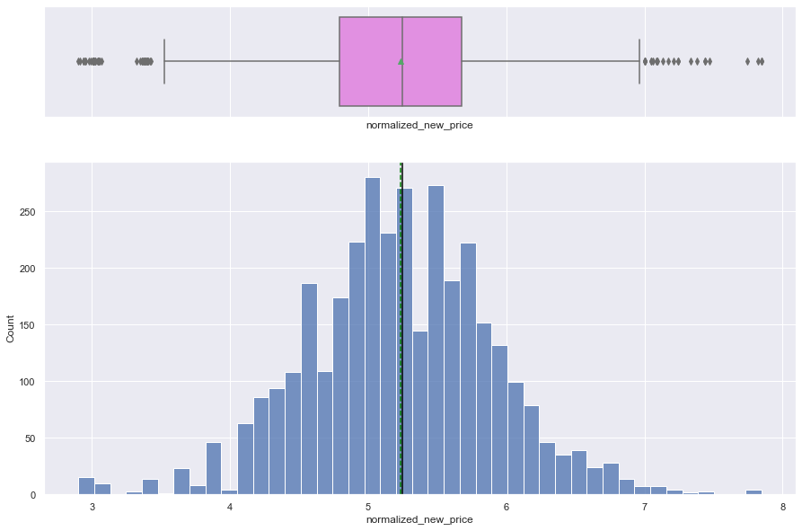

```python
histogram_boxplot(df, "normalized_new_price")
```

- The average normalized_new_price is 5.2 euros.
- This is a bimodal distribution.

**`screen_size`**

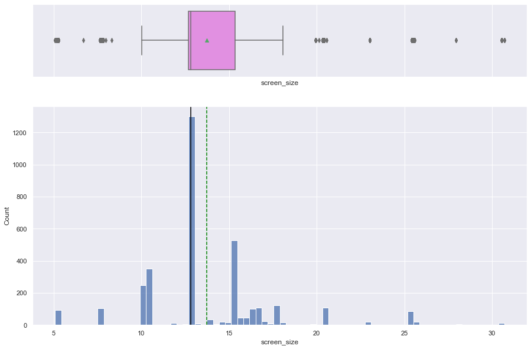

```python
histogram_boxplot(df, "screen_size")
```

- The most common screen size is 13cm.

**`main_camera_mp`**

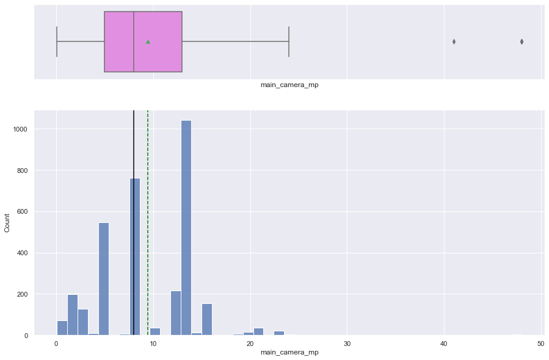

```python
histogram_boxplot(df, "main_camera_mp")
```

**`selfie_camera_mp`**

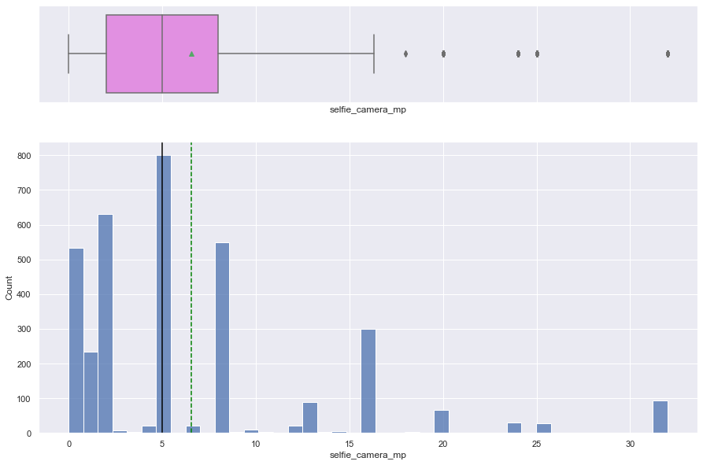

```python
histogram_boxplot(df, "selfie_camera_mp")
```

**`ram`**

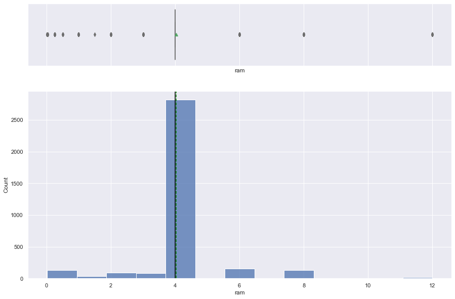

```python
histogram_boxplot(df, "ram")
```

- The most common RAM size is 4GB.

**`int_memory`**

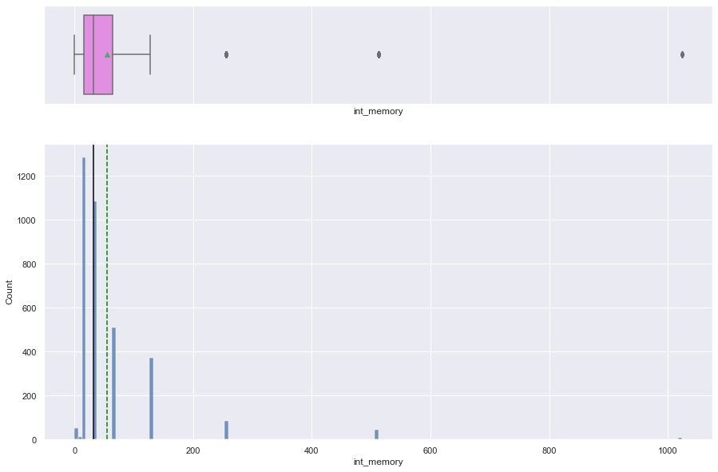

```python
histogram_boxplot(df, "int_memory")
```

**`weight`**

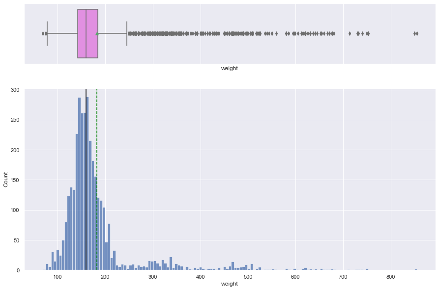

```python
histogram_boxplot(df, "weight")
```

**`battery`**

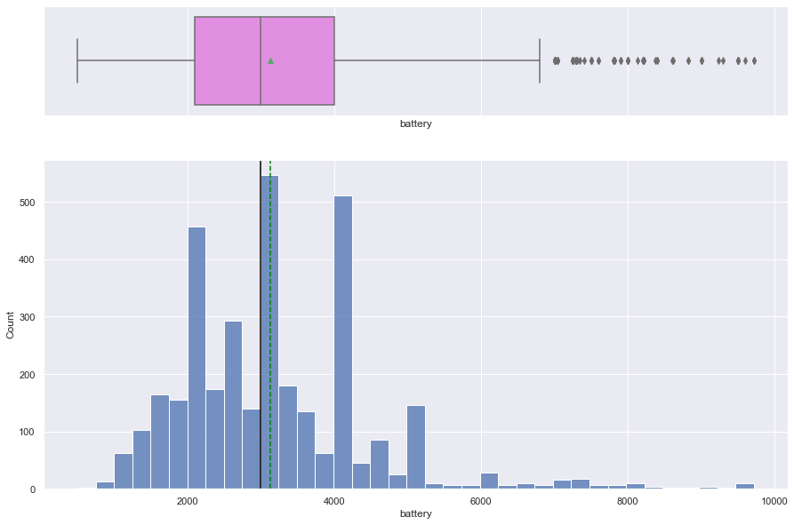

```python
histogram_boxplot(df, "battery")
```

**`days_used`**

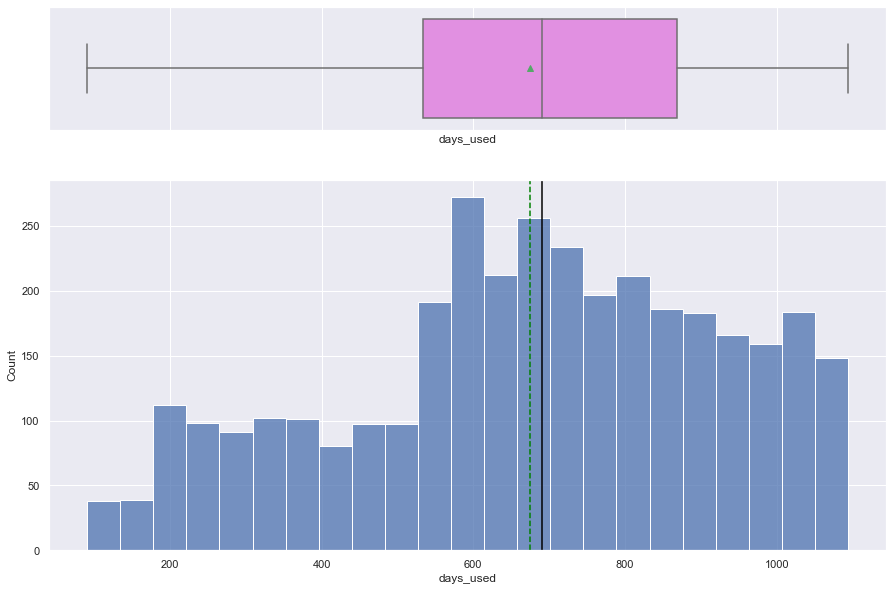

```python
histogram_boxplot(df, "days_used")
```

**`brand_name`**

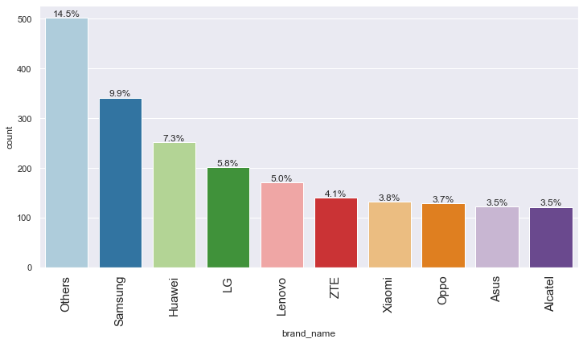

```python
labeled_barplot(df, "brand_name", perc=True, n=10)
```

**`os`**

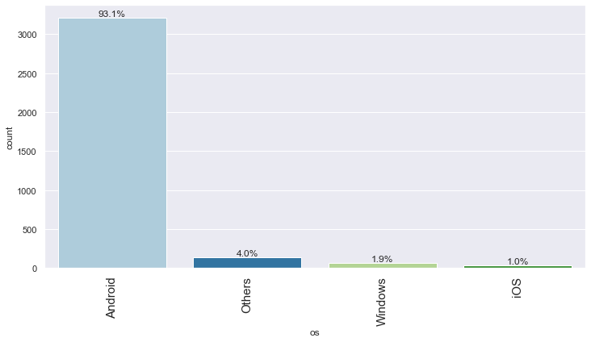

```python
labeled_barplot(df, "os", perc=True, n=10)
```

- 93.1% of the used device market is dominated by Android devices
- One percent of the devices in the used device market has an OS of iOS.

**`4g`**

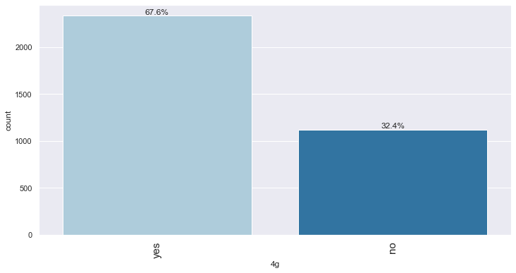

```python
labeled_barplot(df, "4g", perc=True, n=10)
```

- 67.6% of the devices are 4g and 32.4% are not 4g

**`5g`**

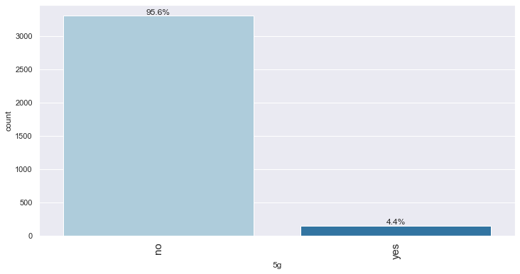

```python
labeled_barplot(df, "5g", perc=True, n=10)
```

- 95.6% of the devices don't have 5g.

**`release_year`**

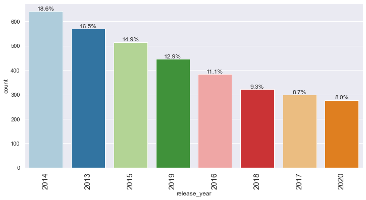

```python
labeled_barplot(df, "release_year", perc=True, n=10)
```

- Most of this devices were released in year 2014.
- 2020 has the least release of devices.

### Bivariate Analysis

**The amount of RAM is important for the smooth functioning of a device. How does the amount of RAM vary with the brand?**

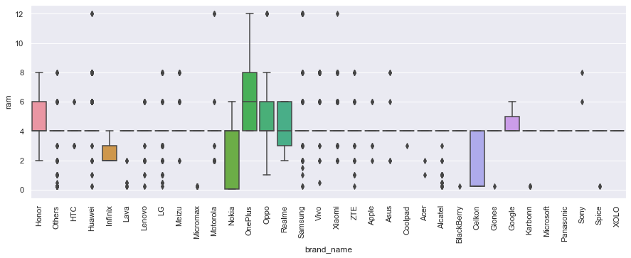

```python
plt.figure(figsize=(15, 5))
sns.boxplot(data=df, x="brand_name", y="ram")
plt.xticks(rotation=90)
plt.show()
```

- Every brand has a 4g ram in their devices.
- The maximum Ram for Oneplus is 12GB.

**A large battery often increases a device's weight, making it feel uncomfortable in the hands. How does the weight vary for phones and tablets offering large batteries (more than 4500 mAh)?**

```python
df_large_battery = df[df.battery > 4500]
df_large_battery.shape
```

```
(341, 15)
```

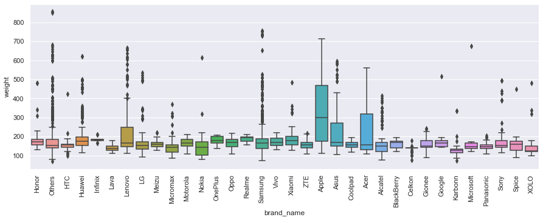

```python
plt.figure(figsize=(15, 5))
sns.boxplot(
    data=df, x="brand_name", y="weight"
)  ##  code showing the relationship between 'brand_name' and 'weight' using a boxplot
plt.xticks(rotation=90)
plt.show()
```

**Bigger screens are desirable for entertainment purposes as they offer a better viewing experience. How many phones and tablets are available across different brands with a screen size larger than 6 inches?**

```python
df_large_screen = df[df.screen_size > 6 * 2.54]
df_large_screen.shape
```

```
(1099, 15)
```

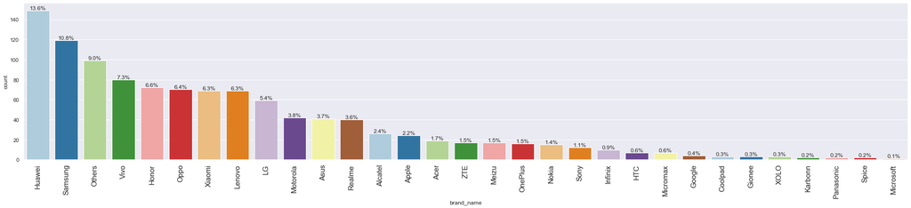

```python
labeled_barplot(
    df_large_screen, "brand_name", perc=True
)  ## labeled_barplot for 'brand_name' in large screen dataframe
```

- Hauwei has the most device with screen size larger than 6 inches.
- Microsoft has the least device with screen size larger than 6 inches.

**A lot of devices nowadays offer great selfie cameras, allowing us to capture our favorite moments with loved ones. What is the distribution of devices offering greater than 8MP selfie cameras across brands?**

```python
df_selfie_camera = df[df.selfie_camera_mp > 8]
df_selfie_camera.shape
```

```
(655, 15)
```

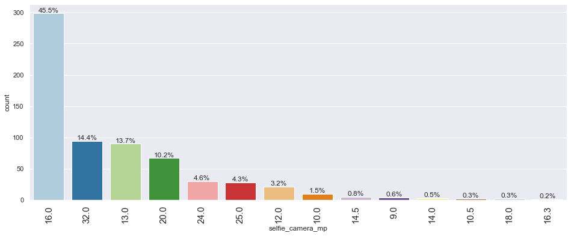

```python
labeled_barplot(
    df_selfie_camera, "selfie_camera_mp", perc=True
)  ## code to create labeled_barplot for 'brand_name' in high selfie camera dataframe
```

- 45% of the devices offer 16MP selfie cameras accross brands.

**Which attributes are highly correlated with the normalized price of a used device?**

**Correlation Check**

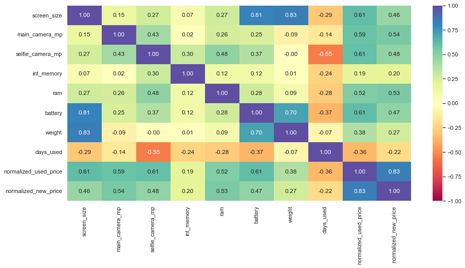

```python
cols_list = df.select_dtypes(include=np.number).columns.tolist()
# dropping release_year as it is a temporal variable
cols_list.remove("release_year")

plt.figure(figsize=(15, 7))
sns.heatmap(
    df[cols_list].corr(), annot=True, vmin=-1, vmax=1, fmt=".2f", cmap="Spectral"
)
plt.show()
```

- Normalized new price, screen size, battery and selfie camera mp have a high correlation with normalized used price of the devices.

## Data Preprocessing

- Missing value treatment
- Feature engineering (if needed)
- Outlier detection and treatment (if needed)
- Preparing data for modeling
- Any other preprocessing steps (if needed)

#### Missing value treatment

```python
# let's create a copy of the data
df1 = df.copy()
```

```python
# checking for missing values
df1.isnull().sum()
```

```
brand_name                 0
os                         0
screen_size                0
4g                         0
5g                         0
main_camera_mp           179
selfie_camera_mp           2
int_memory                 4
ram                        4
battery                    6
weight                     7
release_year               0
days_used                  0
normalized_used_price      0
normalized_new_price       0
dtype: int64
```

```python
cols_impute = [
    "main_camera_mp",
    "selfie_camera_mp",
    "int_memory",
    "ram",
    "battery",
    "weight",
]

for col in cols_impute:
    df1[col] = df1[col].fillna(
        value=df1.groupby(["release_year", "brand_name"])[col].transform("median")
    ) ## code to impute missing values in cols_impute with median by grouping the data on release year and brand name

# checking for missing values
df1.isnull().sum()
```

[output not shown]

- We will impute the remaining missing values in the data by the column medians grouped by `brand_name`.

```python
cols_impute = [
    "main_camera_mp",
    "selfie_camera_mp",
    "battery",
    "weight",
]

for col in cols_impute:
    df1[col] = df1[col].fillna(
        value=df1.groupby(["brand_name"])[col].transform("median")
    )  ## code to impute the missing values in cols_impute with median by grouping the data on brand name

# checking for missing values
df1.isnull().sum()  ## code to check missing values after imputing the above columns
```

```
brand_name                0
os                        0
screen_size               0
4g                        0
5g                        0
main_camera_mp           10
selfie_camera_mp          0
int_memory                0
ram                       0
battery                   0
weight                    0
release_year              0
days_used                 0
normalized_used_price     0
normalized_new_price      0
dtype: int64
```

```python
df1["main_camera_mp"] = df1["main_camera_mp"].fillna(
    df1["main_camera_mp"].median
)  ## code to impute the data with median

# checking for missing values
df1.isnull().sum()
```

```
brand_name               0
os                       0
screen_size              0
4g                       0
5g                       0
main_camera_mp           0
selfie_camera_mp         0
int_memory               0
ram                      0
battery                  0
weight                   0
release_year             0
days_used                0
normalized_used_price    0
normalized_new_price     0
dtype: int64
```

- There is no more missing value

### Feature Engineering

- Let's create a new column `years_since_release` from the `release_year` column.
- We will consider the year of data collection, 2021, as the baseline.
- We will drop the `release_year` column.

```python
df1["years_since_release"] = 2021 - df1["release_year"]
df1.drop("release_year", axis=1, inplace=True)
df1["years_since_release"].describe()
```

```
count    3454.000000
mean        5.034742
std         2.298455
min         1.000000
25%         3.000000
50%         5.500000
75%         7.000000
max         8.000000
Name: years_since_release, dtype: float64
```

### Outlier detection

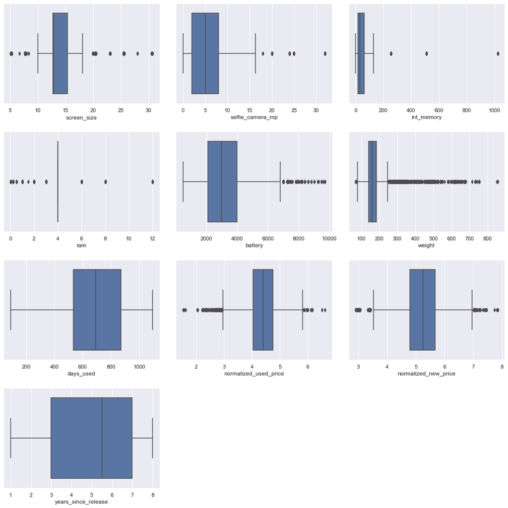

```python
# outlier detection using boxplot
num_cols = df1.select_dtypes(include=np.number).columns.tolist()

plt.figure(figsize=(15, 15))

for i, variable in enumerate(num_cols):
    plt.subplot(4, 3, i + 1)
    sns.boxplot(data=df1, x=variable)
    plt.tight_layout(pad=2)

plt.show()
```

- There are quite a few outliers in the data
- However, we will not treat them as they are proper values

### Data Preparation for Modeling

- We want to predict the normalized price of used devices
- Before we proceed to build a model, we'll have to encode categorical features
- We'll split the data into train and test to be able to evaluate the model that we build on the train data
- We will build a Linear Regression model using the train data and then check it's performance

```python
# defining X and y variables
X = df1.drop(["normalized_used_price"], axis=1)
y = df1["normalized_used_price"]

print(X.head())
print()
print(y.head())
```

```
  brand_name       os  screen_size   4g   5g main_camera_mp  selfie_camera_mp  \
0      Honor  Android        14.50  yes   no           13.0               5.0
1      Honor  Android        17.30  yes  yes           13.0              16.0
2      Honor  Android        16.69  yes  yes           13.0               8.0
3      Honor  Android        25.50  yes  yes           13.0               8.0
4      Honor  Android        15.32  yes   no           13.0               8.0

   int_memory  ram  battery  weight  days_used  normalized_new_price  \
0        64.0  3.0   3020.0   146.0        127              4.715100
1       128.0  8.0   4300.0   213.0        325              5.519018
2       128.0  8.0   4200.0   213.0        162              5.884631
3        64.0  6.0   7250.0   480.0        345              5.630961
4        64.0  3.0   5000.0   185.0        293              4.947837

   years_since_release
0                    1
1                    1
2                    1
3                    1
4                    1

0    4.307572
1    5.162097
2    5.111084
3    5.135387
4    4.389995
Name: normalized_used_price, dtype: float64
```

```python
# let's add the intercept to data
X = sm.add_constant(X)
```

```python
# creating dummy variables
X = pd.get_dummies(
    X,
    columns=X.select_dtypes(include=["object", "category"]).columns.tolist(),
    drop_first=True,
)

X.head()
```

|  | const | screen_size | selfie_camera_mp | int_memory | ram | battery | weight | days_used | normalized_new_price | years_since_release | ... | main_camera_mp_20.1 | main_camera_mp_12.6 | main_camera_mp_16.3 | main_camera_mp_22.6 | main_camera_mp_19.0 | main_camera_mp_21.5 | main_camera_mp_21.2 | main_camera_mp_8.1 | main_camera_mp_1.2 | main_camera_mp_22.5 |
| --- | --- | --- | --- | --- | --- | --- | --- | --- | --- | --- | --- | --- | --- | --- | --- | --- | --- | --- | --- | --- | --- |
| 0 | 1.0 | 14.50 | 5.0 | 64.0 | 3.0 | 3020.0 | 146.0 | 127 | 4.715100 | 1 | ... | 0 | 0 | 0 | 0 | 0 | 0 | 0 | 0 | 0 | 0 |
| 1 | 1.0 | 17.30 | 16.0 | 128.0 | 8.0 | 4300.0 | 213.0 | 325 | 5.519018 | 1 | ... | 0 | 0 | 0 | 0 | 0 | 0 | 0 | 0 | 0 | 0 |
| 2 | 1.0 | 16.69 | 8.0 | 128.0 | 8.0 | 4200.0 | 213.0 | 162 | 5.884631 | 1 | ... | 0 | 0 | 0 | 0 | 0 | 0 | 0 | 0 | 0 | 0 |
| 3 | 1.0 | 25.50 | 8.0 | 64.0 | 6.0 | 7250.0 | 480.0 | 345 | 5.630961 | 1 | ... | 0 | 0 | 0 | 0 | 0 | 0 | 0 | 0 | 0 | 0 |
| 4 | 1.0 | 15.32 | 8.0 | 64.0 | 3.0 | 5000.0 | 185.0 | 293 | 4.947837 | 1 | ... | 0 | 0 | 0 | 0 | 0 | 0 | 0 | 0 | 0 | 0 |

5 rows × 89 columns

```python
# splitting the data in 70:30 ratio for train to test data

x_train, x_test, y_train, y_test = train_test_split(X, y, test_size=0.3, random_state=1)
```

```python
print("Number of rows in train data =", x_train.shape[0])
print("Number of rows in test data =", x_test.shape[0])
```

```
Number of rows in train data = 2417
Number of rows in test data = 1037
```

## EDA

- It is a good idea to explore the data once again after manipulating it.

### Univariate Analysis

#### `normalized_used_price`

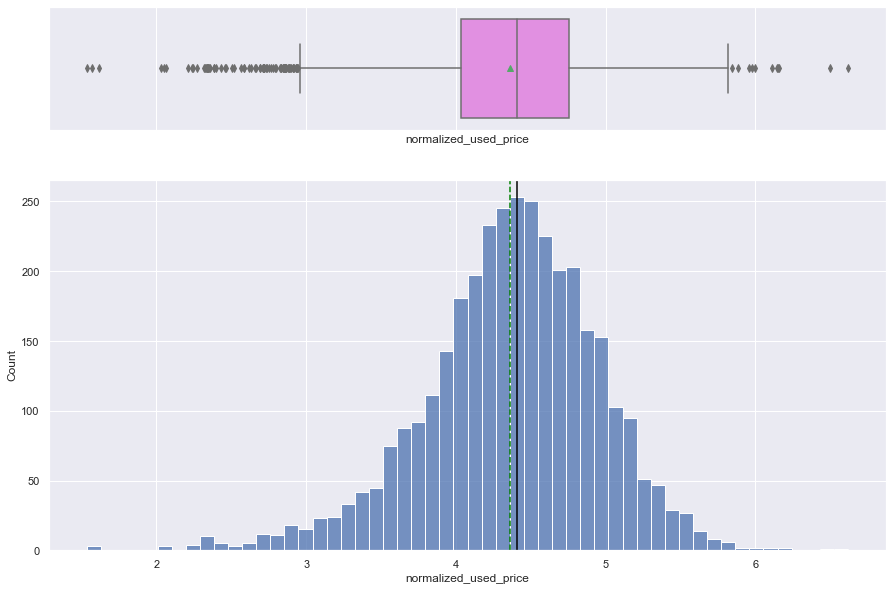

```python
histogram_boxplot(df, "normalized_used_price")
```

#### `normalized_new_price`

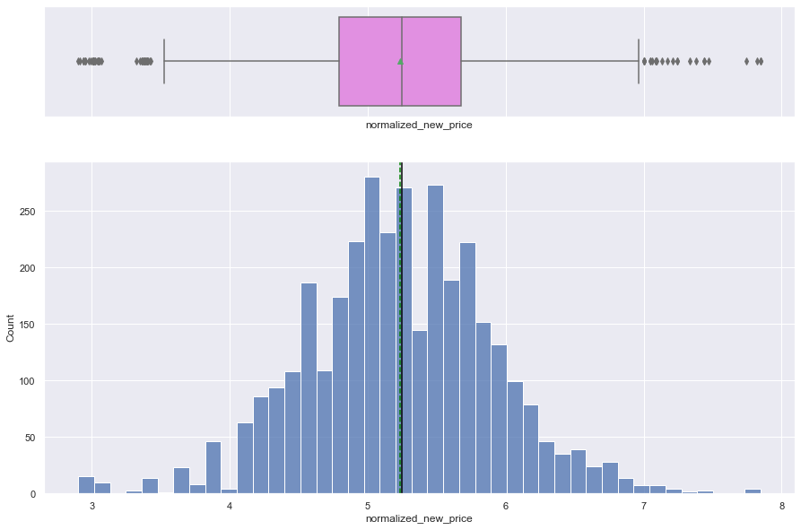

```python
histogram_boxplot(df, "normalized_new_price")
```

**`screen_size`**

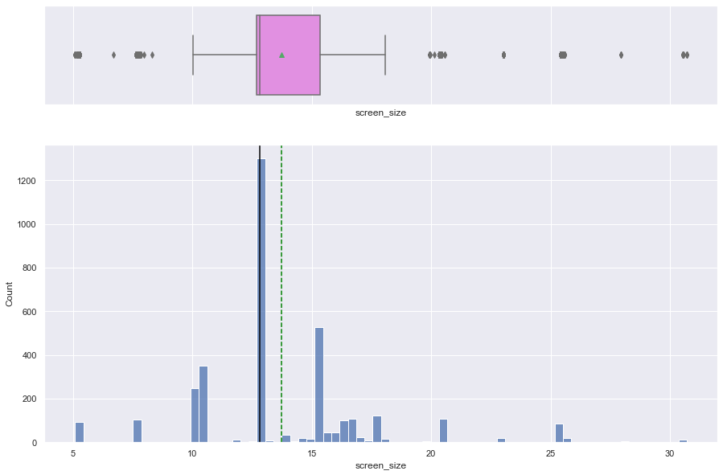

```python
histogram_boxplot(df, "screen_size")
```

**`main_camera_mp`**

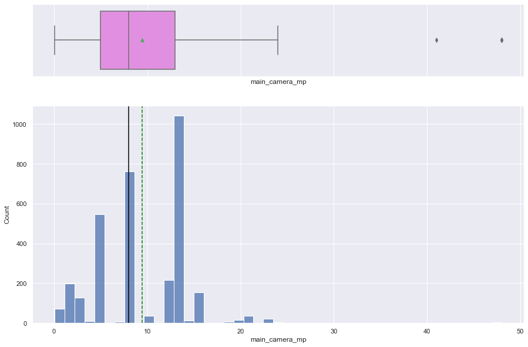

```python
histogram_boxplot(df, "main_camera_mp")
```

**`selfie_camera_mp`**

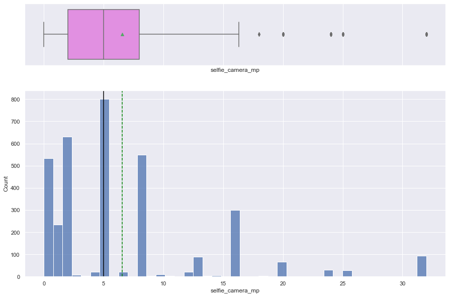

```python
histogram_boxplot(df, "selfie_camera_mp")
```

**`int_memory`**

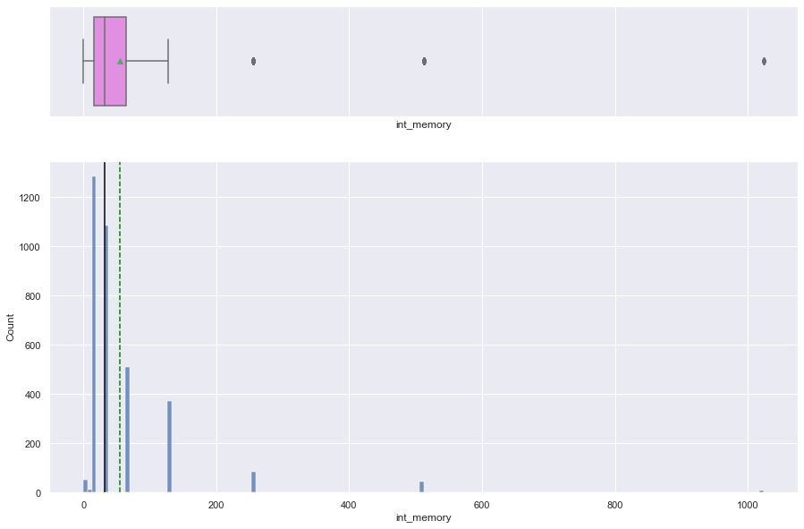

```python
histogram_boxplot(df, "int_memory")
```

**`ram`**

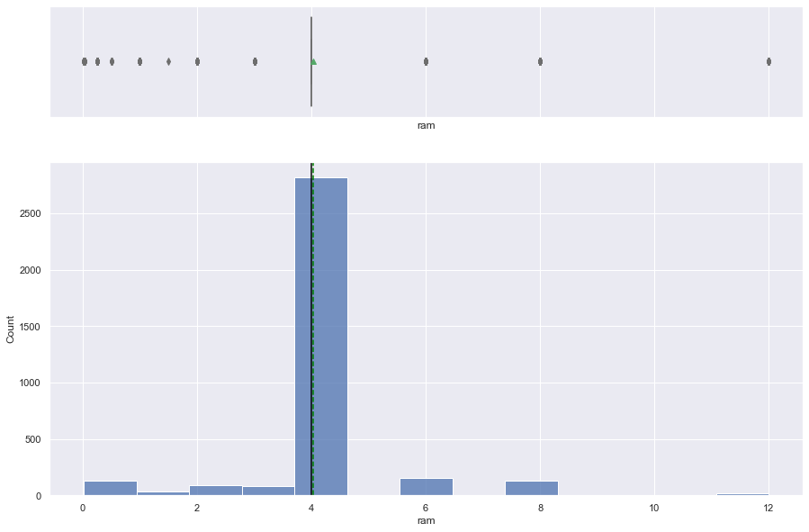

```python
histogram_boxplot(df, "ram")
```

**`weight`**